# S02 - Severidades Individuales

Juan Carlos Martínez-Ovando

Primavera 2017

# Distribución log-normal

Si $X\sim N(x|\mu,\sigma^{2})$ se tiene que
$$\begin{eqnarray}
\mathbb{E}(X) & = & \mu
\nonumber\\
var(X) & = &\sigma^{2}.
\nonumber
\end{eqnarray}$$
Por otro lado, si definimos $Y=\exp\{X\}$ entonces
$$\begin{eqnarray}
\mathbb{E}(Y) & = & \exp\{\mu+\sigma^{2}/2\}
\nonumber\\
var(Y) & = & \left(\exp\{\sigma^{2}\}−1\right)\exp\{2\mu+\sigma^{2}\}.
\nonumber
\end{eqnarray}$$

En R, puede calcularse con la función `dlnorm`, donde `meanlog` y `sdlog` corresponden a $\mu$ and $\sigma$ en la parametrizacion de la distribucion normal de origen. Las siguientes lineas en R ejemplifican esto.

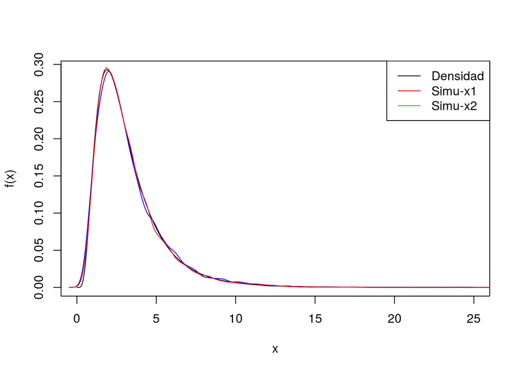

```r
# Media
mean1 <- 1
# Desviacion estandar
sd1 <- 0.6
N.sim <- 10000
# Simulacion a partir de la distribucion normal
x1  <- exp(rnorm(N.sim,mean1,sd1))
# Simulacion a partir de la distribucion log-normal
# parametrizada respecto a la normal
x2  <- rlnorm(N.sim,mean1,sd1)

grid <- seq(0,25,.1)

# Verdadera media de la distribucion log-normal
meanlog1 <- exp(mean1+sd1^2/2)
# Verdadera desviacion estandar de la distribucion log-normal
sdlog1 <- sqrt((exp(sd1^2)-1)*meanlog1^2)
plot(grid, dlnorm(grid,mean1,sd1),
     type="l",xlab="x",ylab="f(x)")
lines(density(x1),col="blue")
lines(density(x2),col="red")

legend("topright",
       c("Densidad","Simu-x1","Simu-x2"),
       lty=1,col=1:3)
```

```r
media <- as.data.frame(c(meanlog1,mean(x1),mean(x2)))
colnames(media) <- c("Media")
rownames(media) <- c("Densidad","Simu-x1","Simu-x2")
sd <- as.data.frame(c(sdlog1,sd(x1),sd(x2)))
colnames(sd) <- c("s.d.")
rownames(sd) <- c("Densidad","Simu-x1","Simu-x2")
media
```

```
##             Media
## Densidad 3.254374
## Simu-x1  3.252425
## Simu-x2  3.242867
```

```r
sd
```

```
##              s.d.
## Densidad 2.142282
## Simu-x1  2.138497
## Simu-x2  2.155409
```

## Algunas caracteristicas

El valor esperado de cualquier funcion integrable $Y$, $\phi(\cdot)$ puede aproximarse mediante el metodo de Monte Carlo. *Debemos considerar este como el ultimo recurso para el calculo, preferenciando siempre los calculos analiticos.*

Recordemos que el valor esperado de $\phi(y)$ respecto a la distribucion log-normal es
$$\begin{eqnarray}
\mathbb{E}(\phi(Y))
& = &
\int \phi(ty) f_Y(y)dy.
\nonumber
\end{eqnarray}$$
Empleando el metodo de Monte Carlo, con base en una muestra i.i.d. $\{y^{(n)}\}_{n=1}^{N}$, tenemos
$$\begin{eqnarray}
\mathbb{E}(\phi(Y))
& \approx &
\frac{1}{N}\sum_{n=1}^{N} \phi\left(y^{(n)}\right).
\nonumber
\end{eqnarray}$$

El siguiente codigo en R ejemplifica este procedimiento, considerando el tamano de muestra $N$ igual a `N.sim`.

```
# Simulacion a partir de la distribucion normal
x1  <- exp(rnorm(N.sim,mean1,sd1))
# Monte Carlo para la generadora de momentos
M.sim <- function(t,x1) mean(exp(x1))
M.teo <- function(t) (3-2*t)/(3-3*t)
t.grid <- seq(-2,1, by=.1)
Mt.grid <- Vectorize(M.sim)(t)
plot(t.grid,Mt.grid,type="b",col='blue')
lines(t.grid,M.teo(t.grid),col="red")
```

Recordemos que el metodo de Monte Carlo es valido para funciones $\phi(\cdot)$ **integrables**. Para la distribucion log-normal existe un ejemplo peculiar de funciones que no son integrables, i.e.
$$\phi(y)=\exp\{ty\},$$
para todo $t$ positivo. Por consiguiente, la funci'on generadora de momentos de la distribucion log-normal **no esta definida**.

Sin embargo, sus momentos existen y pueden calcularse a partir de la siguiente expresion,
$$\begin{equation}
\mathbb{E}(X^k) = \exp\left(\mu k + \sigma^2 k^2 / 2\right),
\end{equation}$$

para todo $k$ entero.

Adicionalmente, los cuantiles para la distribucion log-normal pueden calcularse analiticamente empleando la siguiente expresion
$$\begin{equation}
F_Y^{-1}(\alpha) = \exp\left\{\mu + \sigma \Phi^{-1}(\alpha)\right\},
\end{equation}$$

para todod $0<\alpha<1$, donde $\Phi^{-1}(\cdot)$ es la inversa de la distribucion normal estandar.

## Convolucion

Sabemos que si tenemos variables aleatorias $X_i \sim N(x|\mu_i,\sigma_i^2)$ independientes, entonces la distribucion de la suma $S=\sum_{i=1}^{n}$ es
$$S \sim N\left(s|\sum_{i=1}^{n}\mu_i,\sum_{i=1}^{n}\sigma_1^{2}\right).$$
Tarea: Que pasa con la suma de variables aleatorias log-normales?